# Omics Data Analysis Report: datasets_LABOS2023

Mariangela Santorsola

03/01/2024

**Important** Please double check the path of each file used as input by this document. - quant_path: Here you need to include the path to directory upstream to the single samples, such as:

```
.salmon
├── **control_rep1**
│   ├── aux_info
│   │   ├── ambig_info.tsv
│   │   ├── expected_bias.gz
│   │   ├── fld.gz
│   │   ├── meta_info.json
│   │   ├── observed_bias.gz
│   │   └── observed_bias_3p.gz
│   ├── cmd_info.json
│   ├── libParams
│   │   └── flenDist.txt
│   ├── lib_format_counts.json
│   ├── logs
│   │   └── salmon_quant.log
│   ├── quant.genes.sf
│   └── **quant.sf**
[...]
```

- tx2gene: Make sure to use this gencode.v29.transcripts_no-vers_chr21_tx2gene.txt file.
- ext_funcs: Make sure to include in the path the external functions available in to process VCF file extract_annotations_full.R

# RNAseq data analysis

## Experimental design

[output not shown]

This section contains the results of the RNAseq data analysis.

[output not shown]

## Data Processing

### Read alignment and Quantification

[…]

```bash
nextflow run nf-core/rnaseq -r 3.12.0 \
--input  datasets_lesson33/rnaseq/reads/rnaseq_samplesheet.csv \
--outdir results-in-you-bucket \
--genome GRCh38chr21 \
--pseudo_aligner salmon \
--skip_alignment \
--skip_biotype_qc \
-c rnaseq_nextflow.config \
-profile gls \
--skip_stringtie \
--skip_bigwig \
--skip_umi_extract \
--skip_trimming \
--skip_fastqc
```

- The config file used to launch nf-core/rnaseq is available at rnaseq_nextflow.config

## Differential Expression Analysis

[…]

```r
dataset <- tibble(
  sample = c("control_rep1",
             "control_rep2",
             "control_rep3",
             "treatment_rep1",
             "treatment_rep2",
             "treatment_rep3"),
  condition = c(rep("control", 3),
                rep("case", 3))
)


# Read transcript to gene ID table
tx2gene <- read_tsv(params$tx2gene, col_names = FALSE, show_col_types = FALSE)
#tx2gene$X2 <- paste(tx2gene$X2, tx2gene$X3, sep='_')


# Read quantification files (*.quant) from salmon pseudo-alignment
files <- file.path(params$quant_path, dataset$sample, "quant.sf")
names(files) <- dataset$sample

txi <- tximport(files, type = "salmon", tx2gene = tx2gene)
```

```
## reading in files with read_tsv
```

```
## 1 2 3 4 5 6
## summarizing abundance
## summarizing counts
## summarizing length
```

```r
colnames(txi$counts)
```

```
## [1] "control_rep1"   "control_rep2"   "control_rep3"   "treatment_rep1"
## [5] "treatment_rep2" "treatment_rep3"
```

```r
rownames(dataset) <- colnames(txi$counts)
dds <- DESeqDataSetFromTximport(txi, dataset, ~condition)
```

```
## using counts and average transcript lengths from tximport
```

```r
# Filter min counts >= 10
keep <- rowSums(counts(dds)) >= 10
dds <- dds[keep,]


# set base level to "control"
dds$condition <- relevel(dds$condition, ref = "control")


# Perform Differential Expression Analysis between cases and controls

dds <- DESeq(dds)
```

```
## using 'avgTxLength' from assays(dds), correcting for library size
```

```r
# Extract results table from the dds object
res <- results(dds)
head(results(dds, tidy=TRUE)) #let's look at the results table
```

```
##               row  baseMean log2FoldChange     lfcSE        stat    pvalue
## 1 ENSG00000141956 19163.165    -0.05771017 0.1715949 -0.33631645 0.7366322
## 2 ENSG00000141959  9863.886    -0.02112210 0.1569692 -0.13456205 0.8929581
## 3 ENSG00000142149  2805.680    -0.05822602 0.2027324 -0.28720637 0.7739543
## 4 ENSG00000142156  4734.872     0.11777204 0.1861589  0.63264253 0.5269671
## 5 ENSG00000142166  2087.254     0.01040686 0.3125481  0.03329683 0.9734379
## 6 ENSG00000142168  1383.594    -0.10085992 0.2230770 -0.45213046 0.6511750
##        padj
## 1 0.9834080
## 2 0.9834080
## 3 0.9834080
## 4 0.9804196
## 5 0.9932993
## 6 0.9804196
```

```r
summary(res)
```

```
##
## out of 229 with nonzero total read count
## adjusted p-value < 0.1
## LFC > 0 (up)       : 3, 1.3%
## LFC < 0 (down)     : 0, 0%
## outliers [1]       : 0, 0%
## low counts [2]     : 0, 0%
## (mean count < 71)
## [1] see 'cooksCutoff' argument of ?results
## [2] see 'independentFiltering' argument of ?results
```

```r
### Top Genes by padj
resOrdered <- res[order(res$padj),]
```

### MA plot

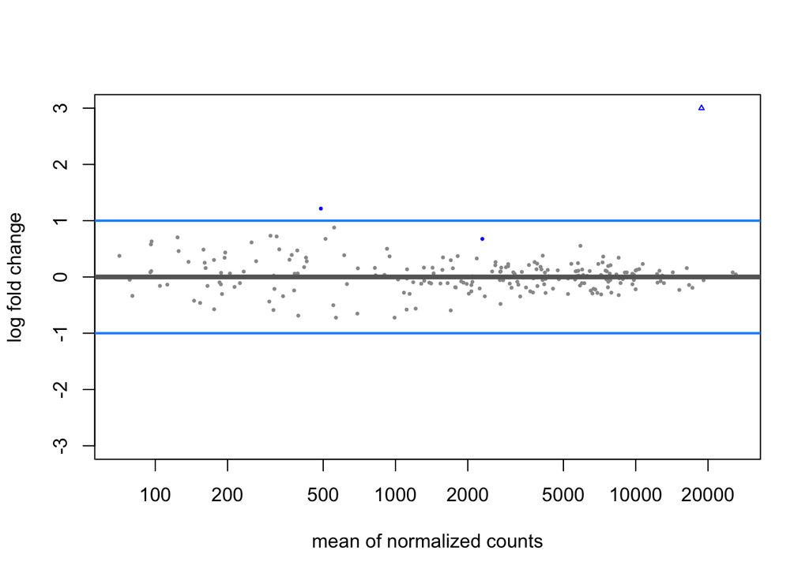

Plot showing the log2 fold change over the mean of normalized counts for analysed samples

### List of Differentially Expressed Genes

| Gene | log2FoldChange | pvalue | padj |
| --- | --- | --- | --- |
| ENSG00000154721 | 3.0462517 | 0.0000000 | 0.0000000 |
| ENSG00000243489 | 1.2146784 | 0.0001044 | 0.0119508 |
| ENSG00000205927 | 0.6759306 | 0.0006984 | 0.0533092 |

# Re-sequencing data analysis

## Experimental design

[…]

## Data Processing

### Variant calling and annotation

[…]

Read vcf file from nf-core/sarek:

```r
vcf <- readVcf(params$vcf)
```

Create the table of annotations by the INFO field within the VCF file:

```r
variants <- rowRanges(vcf)
variants$`REF` <- as.character(variants$`REF`)
variants$ALT <- sapply(variants$ALT, function(x) as.character(x)[1])
variants <- as_tibble(variants)
variants$variantName = names(rowRanges(vcf))
variants = cbind(variants, as_tibble(geno(vcf)$GT))
variants$gene <- unlist(lapply(info(vcf)$ANN, get_most_severe_gene))
variants$ens <- unlist(lapply(info(vcf)$ANN, get_most_severe_ens))
variants$transcript <- unlist(lapply(info(vcf)$ANN, get_most_severe_tr))
variants$aa_change <- unlist(lapply(info(vcf)$ANN, get_most_severe_aa_change))
variants$consequence <- unlist(lapply(info(vcf)$ANN, get_most_severe_consequence))
variants$impact <- unlist(lapply(info(vcf)$ANN, get_most_severe_impact))
```

### Localization and biological consequences of identified mutations

[…]

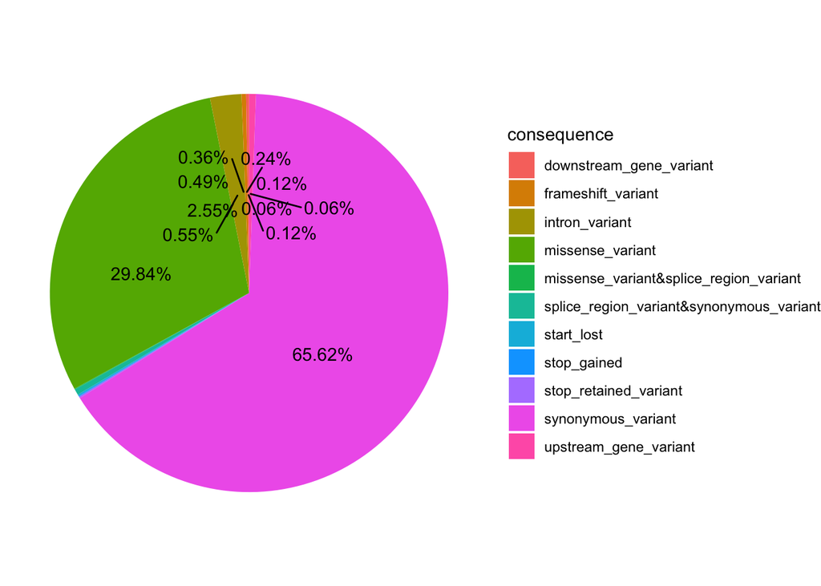

Distribution of the percentage of identified mutations across biological consequence categories

or you can use a table format:

| consequence | count |
| --- | --- |
| synonymous_variant | 1082 |
| missense_variant | 492 |
| intron_variant | 42 |
| upstream_gene_variant | 9 |
| splice_region_variant&synonymous_variant | 8 |
| frameshift_variant | 6 |
| downstream_gene_variant | 4 |
| start_lost | 2 |
| stop_retained_variant | 2 |
| missense_variant&splice_region_variant | 1 |
| stop_gained | 1 |

## Variant Filtering

### Filtering Criteria

[…]

The following *r* and *bash* code block are equivalent, as they output the filtered variants based on the defined criteria:

```r
filteredVars = variants %>%
  filter(control_control1 == "0/0" &
            (impact == "MODERATE" | impact == "HIGH") &
            ens %in% significant_de_genes &
            consequence == "missense_variant")
filteredVars <- as_tibble(filteredVars)
```

or equivalent code in bash

```bash
zcat <vcf.gz> | perl -nae 'if($F[10]=~/0\/0/){print $_;}' | grep 'HIGH\|MODERATE' | grep 'GENE1\|GENE2\|GENE3\|GENE4' | grep missense > mutations_to_check_in_alphamissense.txt
```

### Filtered mutations for further validation assays

| seqnames | start | REF | ALT | gene | consequence | aa_change |
| --- | --- | --- | --- | --- | --- | --- |
| chr21 | 25639842 | C | A | JAM2 | missense_variant | p.His7Gln |
| chr21 | 25693837 | G | A | JAM2 | missense_variant | p.Arg108His |

### Alphamissense Pathogenicity Predictions of filtered variants

You need to search the genes and related protein variants using the Alphamissense portal, you know from the related class.

| seqnames | start | REF | ALT | gene | consequence | aa_change | alphamis_Pathogenicity | alphamis_Class |
| --- | --- | --- | --- | --- | --- | --- | --- | --- |
| chr21 | 25639842 | C | A | JAM2 | missense_variant | p.His7Gln | 0.154 | likely_benign |
| chr21 | 25693837 | G | A | JAM2 | missense_variant | p.Arg108His | 0.139 | likely_benign |

### Gene constraint metrics from gnomAD

| Gene | LOEUF |
| --- | --- |
| JAM | 0.93 |

## Results: Prioritized variant(s)

You can add more information about the prioritized variant(s), such as clinvar significance, variant allele frequency from gnomAD database, and all external tool and resources seen in the course…

[output not shown]

| seqnames | start | REF | ALT | gene | consequence | aa_change | alphamis_Pathogenicity | alphamis_Class | Clinical_significance | gnomAD_AF |
| --- | --- | --- | --- | --- | --- | --- | --- | --- | --- | --- |
| chr21 | 25639842 | C | A | JAM2 | missense_variant | p.His7Gln | 0.154 | likely_benign | Benign | 3.17e-3 |
| chr21 | 25693837 | G | A | JAM2 | missense_variant | p.Arg108His | 0.139 | likely_benign | Pathogenic | 2.48e-6 |